# Graphics with R

Brandon LeBeau

January 23, 2017

We are going to start by exploring graphics with R using the `midwest` data. To access this data, run the following commands:

```r
install.packages("tidyverse")
```

```r
library(tidyverse)
```

Suppose we were interested in exploring the question: How does population density influence the percentage of the population with at least a college degree? Let’s explore these data closer.

| PID | county | state | area | poptotal | popdensity | popwhite | popblack | popamerindian | popasian | popother | percwhite | percblack | percamerindan | percasian | percother | popadults | perchsd | percollege | percprof | poppovertyknown | percpovertyknown | percbelowpoverty | percchildbelowpovert | percadultpoverty | percelderlypoverty | inmetro | category |
| --- | --- | --- | --- | --- | --- | --- | --- | --- | --- | --- | --- | --- | --- | --- | --- | --- | --- | --- | --- | --- | --- | --- | --- | --- | --- | --- | --- |
| 561 | ADAMS | IL | 0.052 | 66090 | 1270.9615 | 63917 | 1702 | 98 | 249 | 124 | 96.71206 | 2.57527614 | 0.14828264 | 0.37675897 | 0.18762294 | 43298 | 75.10740 | 19.631392 | 4.3558594 | 63628 | 96.27478 | 13.151443 | 18.011717 | 11.009776 | 12.443812 | 0 | AAR |
| 562 | ALEXANDER | IL | 0.014 | 10626 | 759.0000 | 7054 | 3496 | 19 | 48 | 9 | 66.38434 | 32.90043290 | 0.17880670 | 0.45172219 | 0.08469791 | 6724 | 59.72635 | 11.243308 | 2.8703153 | 10529 | 99.08714 | 32.244278 | 45.826514 | 27.385647 | 25.228976 | 0 | LHR |
| 563 | BOND | IL | 0.022 | 14991 | 681.4091 | 14477 | 429 | 35 | 16 | 34 | 96.57128 | 2.86171703 | 0.23347342 | 0.10673071 | 0.22680275 | 9669 | 69.33499 | 17.033819 | 4.4885717 | 14235 | 94.95697 | 12.068844 | 14.036061 | 10.852090 | 12.697410 | 0 | AAR |
| 564 | BOONE | IL | 0.017 | 30806 | 1812.1176 | 29344 | 127 | 46 | 150 | 1139 | 95.25417 | 0.41225735 | 0.14932156 | 0.48691813 | 3.69733169 | 19272 | 75.47219 | 17.278954 | 4.1977999 | 30337 | 98.47757 | 7.209019 | 11.179536 | 5.536013 | 6.217047 | 1 | ALU |
| 565 | BROWN | IL | 0.018 | 5836 | 324.2222 | 5264 | 547 | 14 | 5 | 6 | 90.19877 | 9.37285812 | 0.23989034 | 0.08567512 | 0.10281014 | 3979 | 68.86152 | 14.475999 | 3.3676803 | 4815 | 82.50514 | 13.520249 | 13.022889 | 11.143211 | 19.200000 | 0 | AAR |
| 566 | BUREAU | IL | 0.050 | 35688 | 713.7600 | 35157 | 50 | 65 | 195 | 221 | 98.51210 | 0.14010312 | 0.18213405 | 0.54640215 | 0.61925577 | 23444 | 76.62941 | 18.904624 | 3.2758915 | 35107 | 98.37200 | 10.399635 | 14.158819 | 8.179287 | 11.008586 | 0 | AAR |
| 567 | CALHOUN | IL | 0.017 | 5322 | 313.0588 | 5298 | 1 | 8 | 15 | 0 | 99.54904 | 0.01878993 | 0.15031943 | 0.28184893 | 0.00000000 | 3583 | 62.82445 | 11.917388 | 3.2096009 | 5241 | 98.47802 | 15.149781 | 13.787761 | 12.932331 | 21.085271 | 0 | LAR |
| 568 | CARROLL | IL | 0.027 | 16805 | 622.4074 | 16519 | 111 | 30 | 61 | 84 | 98.29813 | 0.66051770 | 0.17851830 | 0.36298721 | 0.49985123 | 11323 | 75.95160 | 16.197121 | 3.0557273 | 16455 | 97.91729 | 11.710726 | 17.225462 | 10.027037 | 9.525052 | 0 | AAR |
| 569 | CASS | IL | 0.024 | 13437 | 559.8750 | 13384 | 16 | 8 | 23 | 6 | 99.60557 | 0.11907420 | 0.05953710 | 0.17116916 | 0.04465282 | 8825 | 72.27195 | 14.107649 | 3.2067989 | 13081 | 97.35060 | 13.875086 | 17.994784 | 11.914343 | 13.660180 | 0 | AAR |
| 570 | CHAMPAIGN | IL | 0.058 | 173025 | 2983.1897 | 146506 | 16559 | 331 | 8033 | 1596 | 84.67331 | 9.57029331 | 0.19130183 | 4.64268169 | 0.92241006 | 95971 | 87.49935 | 41.295808 | 17.7574476 | 154934 | 89.54429 | 15.572437 | 14.132234 | 17.562728 | 8.105017 | 1 | HAU |

[output cut: 427 more lines]

## Create a ggplot

To plot these two variables from the `midwest` data, we will use the function `ggplot` and `geom_point` to add a layer of points. We will treat `popdensity` as the x variable and `percollege` as the y variable.

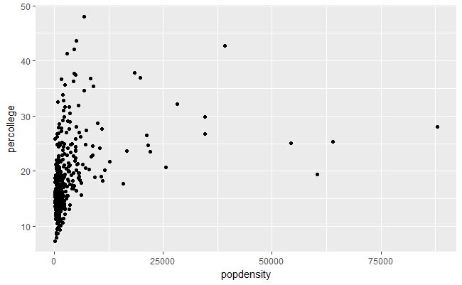

```r
ggplot(data = midwest) +
  geom_point(mapping = aes(x = popdensity, y = percollege))
```

### Examples

1. Try plotting `popdensity` by `state`.
2. Try plotting `county` by `state`. Does this plot work?
3. Bonus: Try just using the `ggplot(data = midwest)` from above. What do you get? Does this make sense?

Note: You should be able to modify the structure of the code above to do this.

## Add Aesthetics

Aesthetics are a way to explore more complex interactions within the data. Particularly, from the above example, lets add in the state variable to the plot via an aesthetic.

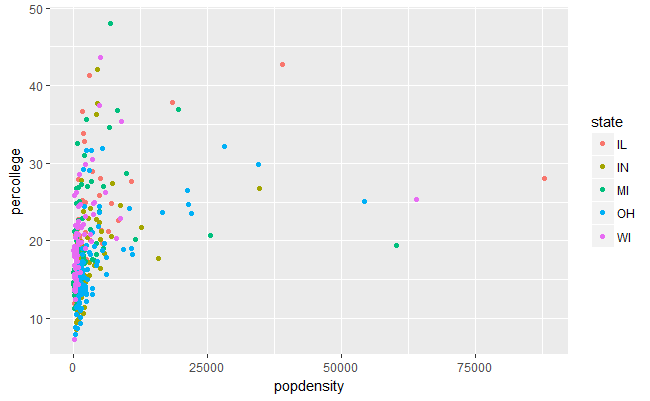

```r
ggplot(data = midwest) +
  geom_point(mapping = aes(x = popdensity, y = percollege, color = state))
```

As you can see, we simply colored the points by the state they belong in. Does there appear to be a trend?

### Examples

1. Using the same aesthetic structure as above, instead of using colors, make the shape of the points different for each state.
2. Instead of color, use `alpha` instead. What does this do to the plot?

## Global Aesthetics

Above, we specified a variable to an aesthetic, which is a common use of aesthetics. However, the aesthetics can also be assigned globally. Here are two examples using the first scatterplot created.

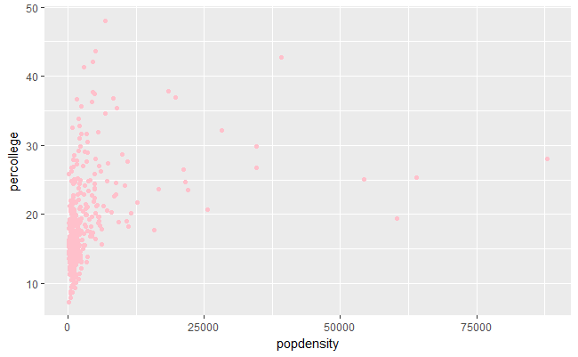

```r
ggplot(data = midwest) +
  geom_point(mapping = aes(x = popdensity, y = percollege), color = 'pink')
```

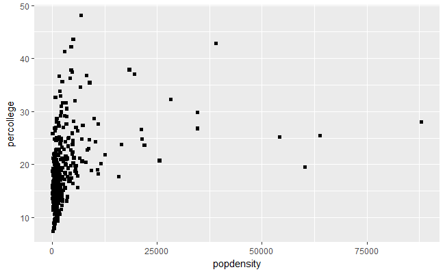

```r
ggplot(data = midwest) +
  geom_point(mapping = aes(x = popdensity, y = percollege), shape = 15)
```

These two plots changed the aesthetics for all of the points. Notice, the suttle difference between the code for these plots and that for the plot above. The placement of the aesthetic is crucial, if it is within the parentheses for `aes()` then it should be assigned a variable. If it is outside, as in the last two examples, it will define the aesthetic for all the data.

### Examples

1. Try the following command: `colors()`. This will print a vector of all the color names within R, try a few to find your favorites.
2. What happens if you use the following code:

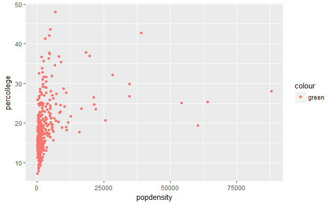

```r
ggplot(data = midwest) +
  geom_point(mapping = aes(x = popdensity, y = percollege, color = 'green'))
```

What is the problem?

## Facets

Instead of defining an aesthetic to change the color or shape of points by a third variable, we can also plot each groups data in a single plot and combine them. The process is easy with `ggplot2` by using facets.

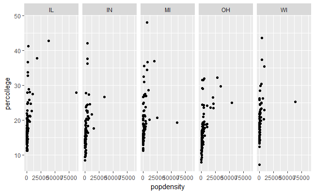

```r
ggplot(data = midwest) +
  geom_point(mapping = aes(x = popdensity, y = percollege)) +
  facet_grid(. ~ state)
```

You can also use `facet_wrap`.

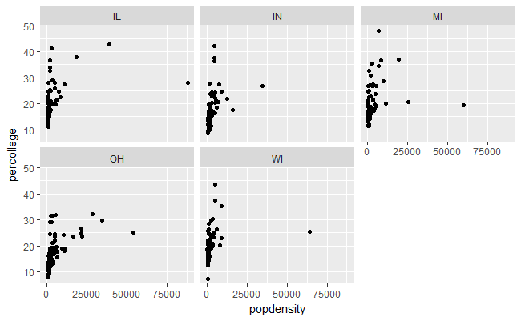

```r
ggplot(data = midwest) +
  geom_point(mapping = aes(x = popdensity, y = percollege)) +
  facet_wrap(~ state)
```

### Examples

1. Can you facet with a continuous variable? Try it!

## Geoms

`ggplot2` uses a grammar of graphics which makes it easy to switch different plot types (called geoms) once you are comfortable with the basic syntax. For example, how does the following plot differ from the scatterplot first generated above? What is similar?

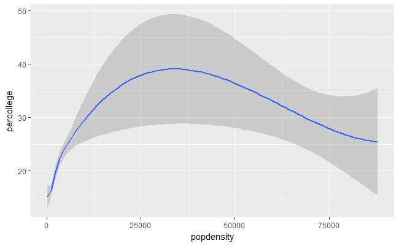

```r
ggplot(data = midwest) +
  geom_smooth(mapping = aes(x = popdensity, y = percollege))
```

We can also do this plot by states

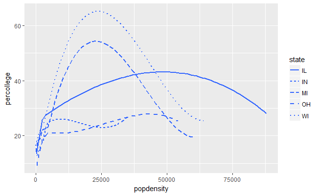

```r
ggplot(data = midwest) +
  geom_smooth(mapping = aes(x = popdensity, y = percollege, linetype = state),
              se = FALSE)
```

What about the code above gave me the different lines for each state? Note, I also removed the standard error shading from the plot as well.

## Combining multiple geoms

Combining more than one geom into a single plot is relatively straightforward, but a few considerations are important. Essentially to do the task, we just simply need to combine the two geoms we have used:

```r
ggplot(data = midwest) +
  geom_point(aes(x = popdensity, y = percollege, color = state)) +
  geom_smooth(mapping = aes(x = popdensity, y = percollege, color = state),
              se = FALSE)
```

[output not shown]

A couple points about combining geoms, first, the order matters. In the above example, we called `geom_point` first, then `geom_smooth`. When plotting these data, the points will then be plotted first followed by the lines. Try flipping the order of the two geoms to see how the plot differs.

We can also simplify this code to not duplicate typing:

```r
ggplot(data = midwest, mapping = aes(x = popdensity, y = percollege, color = state)) +
  geom_point() +
  geom_smooth(se = FALSE)
```

[output not shown]

### Examples

1. Can you recreate the following figure?

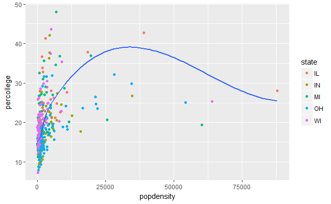

## Other geom examples

There are many other geoms available to use. To see them all, visit http://docs.ggplot2.org/current/index.html which gives examples of all the possibilities. This is a handy resource that I keep going back to.

### Geoms for single variables

The introduction to plotting has been with two variables, but lets take a step back and focus on one variable with a bar chart.

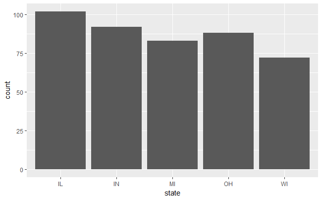

```r
ggplot(data = midwest, mapping = aes(x = state)) +
  geom_bar()
```

You can also easily add aesthetics this base plot as shown before.

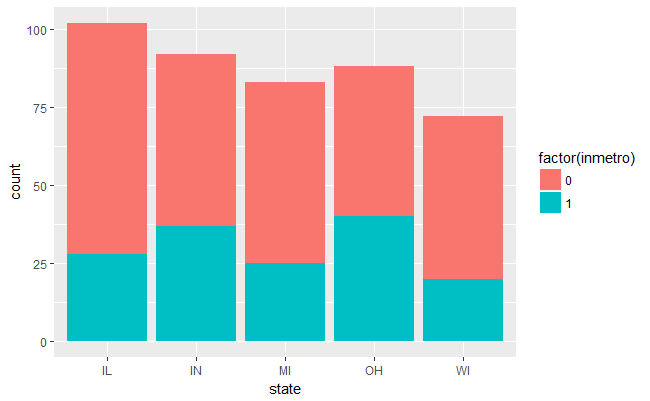

```r
ggplot(data = midwest, mapping = aes(x = state)) +
  geom_bar(aes(fill = factor(inmetro)))
```

A few additions can help interpretation of this plot:

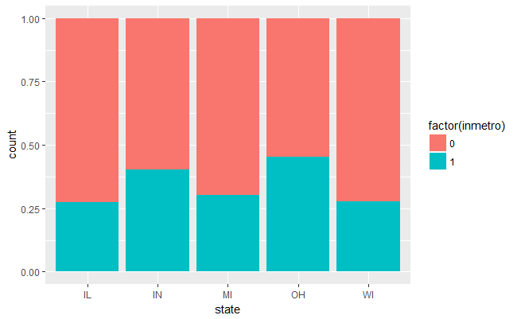

```r
ggplot(data = midwest, mapping = aes(x = state)) +
  geom_bar(aes(fill = factor(inmetro)), position = 'fill')
```

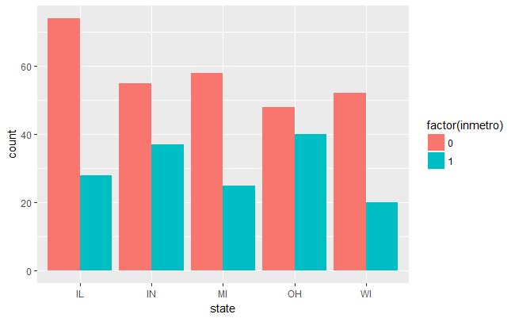

```r
ggplot(data = midwest, mapping = aes(x = state)) +
  geom_bar(aes(fill = factor(inmetro)), position = 'dodge')
```

It is also possible to do a histrogram of a quantitative variable:

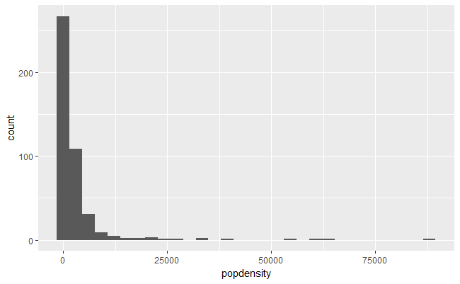

```r
ggplot(data = midwest, mapping = aes(x = popdensity)) +
  geom_histogram()
```

You can adjust the binwidth directly:

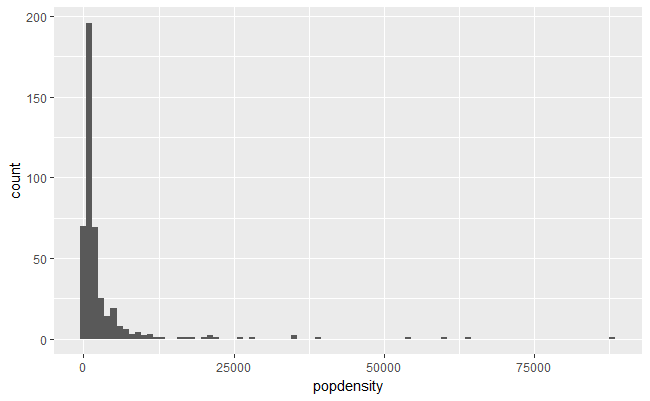

```r
ggplot(data = midwest, mapping = aes(x = popdensity)) +
  geom_histogram(binwidth = 1000)
```

### Examples

1. With more than two groups, histograms are difficult to interpret due to overlap. Instead, use the `geom_density` to create a density plot for `popdensity` for each state. The final plot should look similar to this:

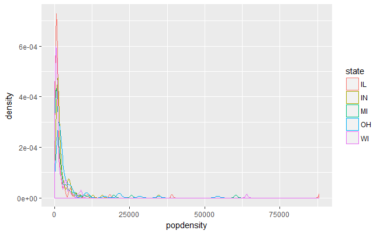

2. Using `geom_boxplot`, create boxplots with `popdensity` as the y variable and `state` as the x variable. Bonus: facet this plot by the variable `inmetro`.

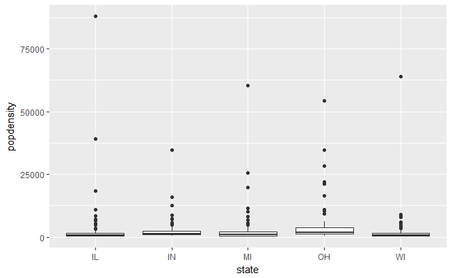

## Plot Customization

There are many many ways to adjust the look of the plot, I will discuss a few that are common.

### Change axes

Axes are something that are commonly altered, particularly to give them a good name and also to alter the values shown on the axes. These are generally done with `scale_x_*` and `scale_y_*` where `*` is a filler based on the type of variable on the axes.

For example:

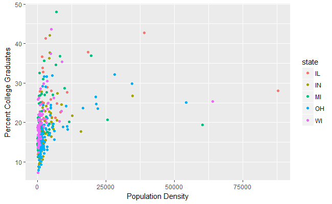

```r
ggplot(data = midwest, mapping = aes(x = popdensity, y = percollege, color = state)) +
  geom_point() +
  scale_x_continuous("Population Density") +
  scale_y_continuous("Percent College Graduates")
```

To change the legend title, the `scale_color_discrete` command can be used to adjust the color aesthetic and the variable is discrete.

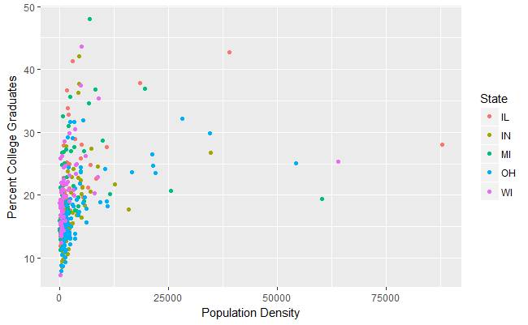

```r
ggplot(data = midwest, mapping = aes(x = popdensity, y = percollege, color = state)) +
  geom_point() +
  scale_x_continuous("Population Density") +
  scale_y_continuous("Percent College Graduates") +
  scale_color_discrete("State")
```

we can also alter the breaks showing on the x-axis.

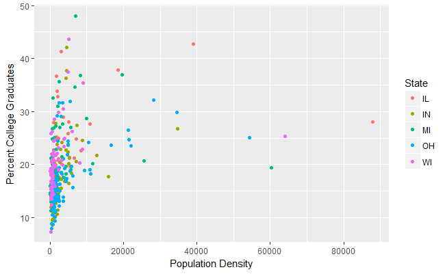

```r
ggplot(data = midwest, mapping = aes(x = popdensity, y = percollege, color = state)) +
  geom_point() +
  scale_x_continuous("Population Density", breaks = seq(0, 80000, 20000)) +
  scale_y_continuous("Percent College Graduates") +
  scale_color_discrete("State")
```

## Zoom in on plot

You’ll notice that there are outliers in this scatterplot due to larger population density values for some counties. It may be of interest to zoom in on the plot. The plot can be zoomed in by using the `coord_cartesian` command as follows.

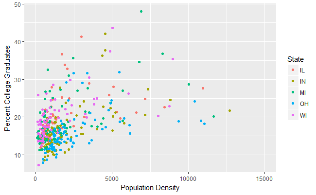

```r
ggplot(data = midwest, mapping = aes(x = popdensity, y = percollege, color = state)) +
  geom_point() +
  scale_x_continuous("Population Density") +
  scale_y_continuous("Percent College Graduates") +
  scale_color_discrete("State") +
  coord_cartesian(xlim = c(0, 15000))
```

Note: This can also be achieved using the `xlim` argument to `scale_x_continuous` above, however this will cause some points to not be plotted. In this case it would not be a huge deal, however, if we plotted the smooth lines from before you can see the difference.

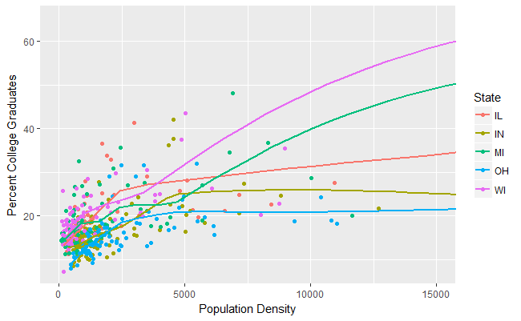

```r
ggplot(data = midwest, mapping = aes(x = popdensity, y = percollege, color = state)) +
  geom_point() +
  geom_smooth(se = FALSE) +
  scale_x_continuous("Population Density") +
  scale_y_continuous("Percent College Graduates") +
  scale_color_discrete("State") +
  coord_cartesian(xlim = c(0, 15000))
```

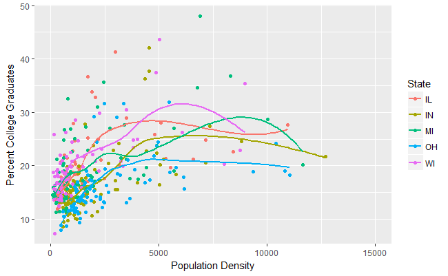

```r
ggplot(data = midwest, mapping = aes(x = popdensity, y = percollege, color = state)) +
  geom_point() +
  geom_smooth(se = FALSE) +
  scale_x_continuous("Population Density", limits = c(0, 15000)) +
  scale_y_continuous("Percent College Graduates") +
  scale_color_discrete("State")
```